# Re-re-analysis of Gatti et al (2014) data

I’ll first load some libraries:

```r
library(broman)
library(qtl2)
library(qtl2convert)
library(data.table)
```

I’ll next load the original data, which were taken from the Mouse Phenome Database, https://phenome.jax.org/projects/Gatti2. The `JAXWEST.additive.Rdata` file was extracted from `Gatti_2014.zip` at MPDcontains a single object `probs`; the phenotype data are in a single CSV file.

```r
load("JAXWEST.additive.Rdata") # contains probs
phe <- fread("Gatti_2014_pheno.csv", data.table=FALSE)

# check that the sample IDs are the same
stopifnot(all(rownames(probs) == phe$Sample.ID))
```

I’ll further load the SNP information, taken from ftp://ftp.jax.org/MUGA.

```r
load("muga_snps.Rdata") # contains muga_snps
```

I’ll now convert the data to R/qtl2 formats:

- Create an `is_female` logical vector
- Convert the genotype probabilities
- Convert the physical and genetic maps
- Pull out the desired covariates and the phenotype to be scanned.

```r
# is_female object
is_female <- setNames(phe$Sex=="F", phe$Sample.ID)

# convert probs to R/qtl2 format
apr_doqtl <- probs_doqtl_to_qtl2(probs, muga_snps, is_female=is_female, marker_column="marker")

# genetic and physical maps
gmap_doqtl <- map_df_to_list(muga_snps)
pmap_doqtl <- map_df_to_list(muga_snps, pos_column="pos")

# covariates + phenotype for scan
addcovar <- cbind(sex=(phe$sex=="M")*1,
                  wbc=log10(phe$WBC))
pheno <- cbind(neut=log10(phe$NEUT))
rownames(pheno) <- rownames(addcovar) <- phe$Sample.ID
```

I’ll now calculate the kinship matrix and perform a genome scan. I’m following what’s described in [Gatti et al (2014)](https://doi.org/10.1534/g3.114.013748)

> We regressed log neutrophil counts on founder allele dosages at each marker using a kinship correction with sex and log white blood cell counts as covariates.

```r
# kinship
k_doqtl <- calc_kinship(apr_doqtl, cores=0)

# genome scan
out_doqtl <- scan1(apr_doqtl, pheno, k_doqtl, addcovar=addcovar, cores=0)
```

For comparison, I’ll calculate the results using R/qtl2-based allele dosages.

```r
apr_rqtl2 <- readRDS("../R/cache/aprobs.rds")

# load the corresponding maps
load("../R/cache/maps_n_phe.RData")
gmap_rqtl2 <- insert_pseudomarkers(gmap[1:20], stepwidth="max", step=0.2)
pmap_rqtl2 <- interp_map(gmap_rqtl2, gmap[1:20], pmap[1:20])

# check that the IDs are the same
stopifnot( all(rownames(apr_rqtl2[[1]]) == rownames(apr_doqtl[[1]])) )

k_rqtl2 <- calc_kinship(apr_rqtl2, cores=0)
out_rqtl2 <- scan1(apr_rqtl2, pheno, k_rqtl2, addcovar=addcovar, cores=0)
```

Here are the results, with the DOQTL probabilities on top and the R/qtl2 probabilities below. As you can see, the LOD score on chr 7 increases a bit with the R/qtl2 probabilities (from 6.0 to 6.5). There’s an even bigger increase if we use the “loco” method, which I had done in the R/qtl2 paper, but which was not done in Gatti et al. (2014).

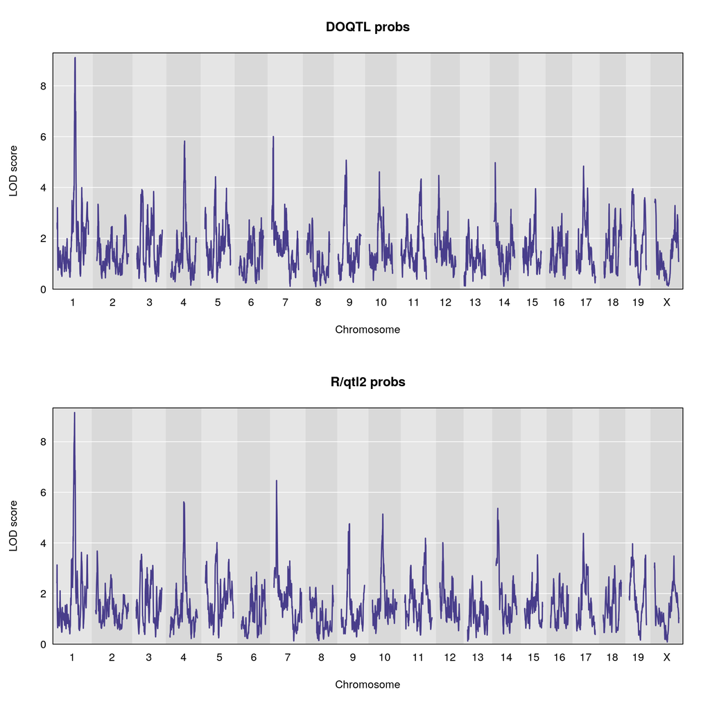

```r
par(mfrow=c(2,1))
plot(out_doqtl, gmap_doqtl, main="DOQTL probs")
plot(out_rqtl2, gmap_rqtl2, main="R/qtl2 probs")
```

Let’s further perform SNP scans in the key region on chr 1.

```r
# scan SNPs in chr 1 region
qv <- create_variant_query_func("~/Data/CCdb/cc_variants.sqlite")
out_snps_doqtl <- scan1snps(apr_doqtl, pmap_doqtl, pheno, k_doqtl, addcovar, query_func=qv,
                          chr=1, start=127, end=134, cores=0, keep_all_snps=TRUE)
out_snps_rqtl2 <- scan1snps(apr_rqtl2, pmap_rqtl2, pheno, k_rqtl2, addcovar, query_func=qv,
                          chr="1", start=127, end=134, cores=0, keep_all_snps=TRUE)
```

Here is a plot of the results, with the results with the DOQTL probabilities on the top and those with the R/qtl2 probabilities on the bottom. The second set of interesting SNPs are not nearly so interesting with the original DOQTL probabilities.

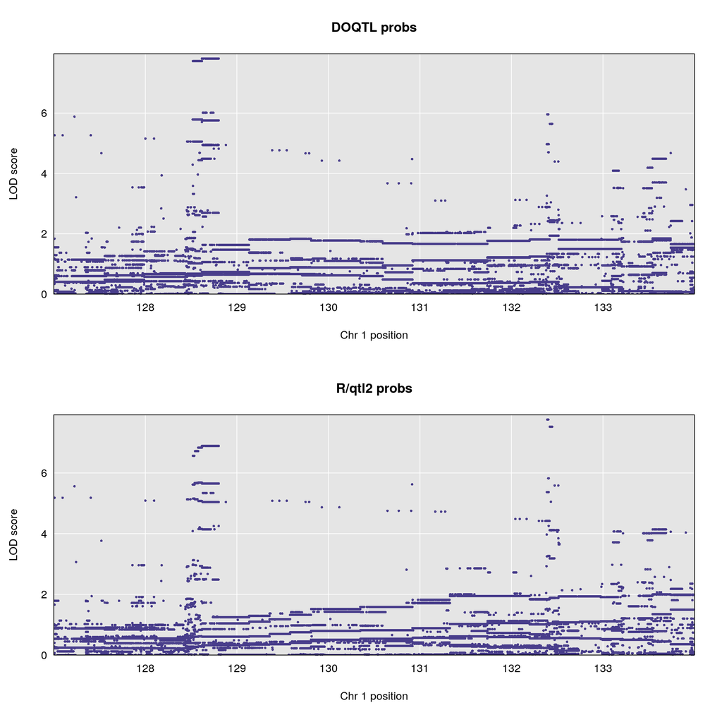

```r
par(mfrow=c(2,1))
plot(out_snps_doqtl$lod, out_snps_doqtl$snpinfo, main="DOQTL probs")
plot(out_snps_rqtl2$lod, out_snps_rqtl2$snpinfo, main="R/qtl2 probs")
```